# Lab 9 - Solutions

```r
library(tidyverse)
```

We want to generate sample data for the coin tossing example. We could use

```r
## coin tossing example. 10 throws. Count n. heads, repeat 20 times.
## Assume normal distribution with mean 5 and SD mean/3.5


set.seed(123) # ensure random sampling will give same values every time with this seed.
minVal <- 0 # set min value
maxVal <- 10 # set max value
mn <- (maxVal - minVal)/2 # average
# Generate 20 numbers (mostly) from min to max
x <- rnorm(20, mean = mn, sd = mn/3.5)
# Change the out-of-bounds generated values to min o max value
x <- pmax(minVal, x)
x <- pmin(maxVal, x)
# round all values as coin tossing produces integers (number of heads out of 10 throws)
x <- round(x)
x
```

```
##  [1] 4 5 7 5 5 7 6 3 4 4 7 6 6 5 4 8 6 2 6 4
```

## Creating the dataset

The dataset includes and instance number and a time value. There are 10 instances.

```r
instance =c(1:10)
time = c(386.1, 386.1, 389.6, 406.1, 407.5, 424.0, 427.5, 429.5, 443.3, 457.8 )
swTimes <- data.frame(instance , time)
```

# Testing for normality

## Q-Q Plot

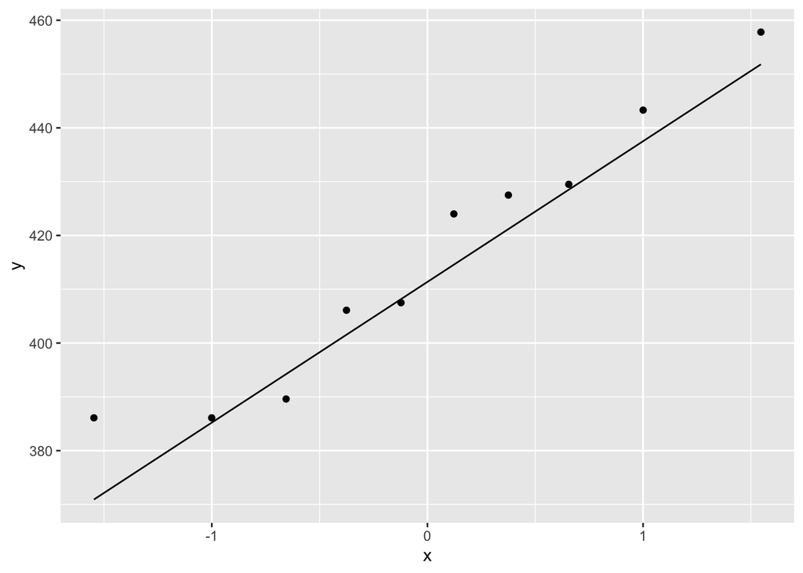

```r
p <- ggplot(swTimes, aes(sample = time))
p <- p + stat_qq()
p <- p + stat_qq_line( )
p
```

Points scatered close to ideal line so is is reasonable to assume that the distribution is normal.

## Shapiro Wilk test

```r
shapiro.test(swTimes$time)
```

```
##
##  Shapiro-Wilk normality test
##
## data:  swTimes$time
## W = 0.93281, p-value = 0.4761
```

The p-value is > 0.05 so it is reasonable to assume that the distribution is normal.

## Dot plot

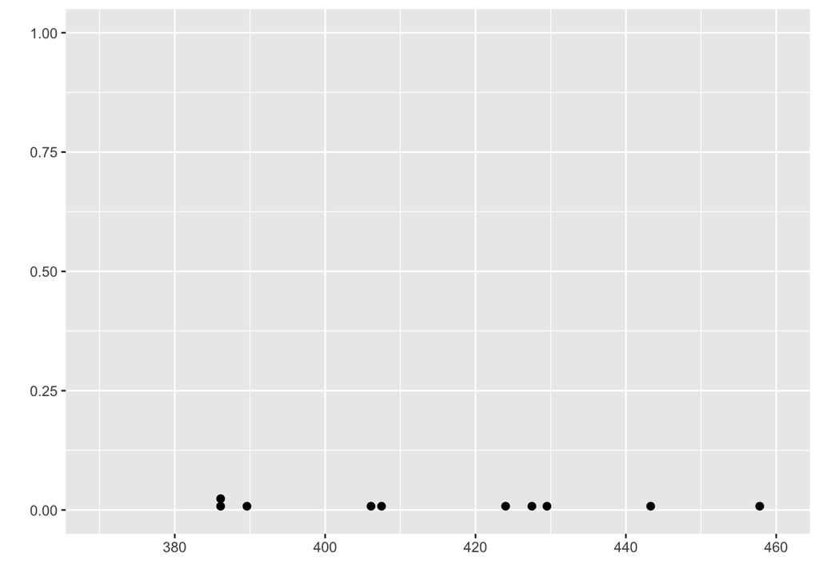

```r
p <- ggplot(swTimes, aes(x= time))
p <- p+ geom_dotplot( binwidth=1 )
p <- p + labs( x="",y="")
p <- p + xlim(370,460)
p
```

The dots are scattered around an area with no pattern. It is not unreasonable to assume that the distribution is normal.

# Confidence intervals and margin of error

# Obtaining the t-value

```r
# number of instances of data
n <- length(swTimes$time)

# Confidence and significance
confidence <- 0.95
significance <- 1- confidence
# two-tailed so half
halfSignificance <- significance/2
a <- 1 - halfSignificance

# degrees of freedom
dfTimes <- n - 1

# finding t-value
# function qt returns required value for t
t <- qt(a, dfTimes)
t
```

```
## [1] 2.262157
```

So the t-value is 2.262157 (at 5% significance level).

# Calculating the margin of error

```r
#standard deviation for times data
sdTimes <- sd(swTimes$time)

# margin of error
error <- t*sdTimes/sqrt(n)
error
```

```
## [1] 17.72528
```

The margin of error is 17.72528.

# Calculating the Confidence interval given margin of error and mean

```r
# mean value
meanTimes <- mean(swTimes$time)
meanTimes
```

```
## [1] 415.75
```

```r
# Lower and upper limits
lowerlimit <- meanTimes - error
upperlimit <- meanTimes + error

# confidence interval
CI <- paste("Confidence interval is (", lowerlimit, ", ",  upperlimit, ")")
CI
```

```
## [1] "Confidence interval is ( 398.024723876052 ,  433.475276123948 )"
```

# One sample t-test

Ho: NULL hypothesis - there is no difference between the mean and value 400 for the swTimes dataset.

H1: Alternative hypothesis - the mean differs from 400.

```r
t.test(swTimes$time, alternative = "two.sided", paired=F, mu= 400, conf.level=0.9)
```

```
##
##  One Sample t-test
##
## data:  swTimes$time
## t = 2.0101, df = 9, p-value = 0.07532
## alternative hypothesis: true mean is not equal to 400
## 90 percent confidence interval:
##  401.3865 430.1135
## sample estimates:
## mean of x
##    415.75
```

# Matched pairs tests

Two search engines are used to identify relevant documents for 12 different searches. Note that the data has been created in a csv file.

```r
engines <- read.csv("engineData.csv", header = T, stringsAsFactors = T)
```

## Testing for normality

### Q-Q Plot

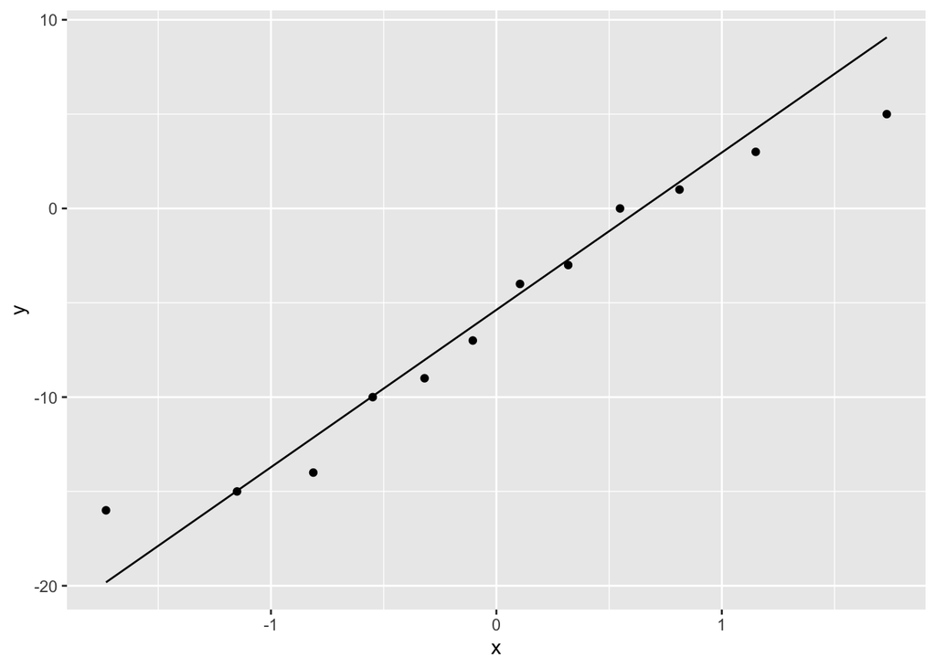

```r
p <- ggplot(engines, aes(sample = Difference))
p <- p + stat_qq()
p<- p + stat_qq_line( )
p
```

The points are scattered close to the line. It is reasonable to assume that the distribution is normal.

### Shapiro-Wilk test of normality

```r
shapiro.test(engines$Difference)
```

```
##
##  Shapiro-Wilk normality test
##
## data:  engines$Difference
## W = 0.9467, p-value = 0.5894
```

The p-value is > 0.05 so it is reasonable to assume that the distribution is normal.

## Paired t-test

Ho: NULL hypothesis - there is no difference between the two search engine means.

H1: Alternative hypothesis – there is a difference between the two search engine means.

```r
t.test(x=engines$Search.engine.A, y=engines$Search.engine.B , alternative = "two.sided", paired=T, mu= 0, conf.level=0.95)
```

```
##
##  Paired t-test
##
## data:  engines$Search.engine.A and engines$Search.engine.B
## t = -2.7664, df = 11, p-value = 0.01834
## alternative hypothesis: true mean difference is not equal to 0
## 95 percent confidence interval:
##  -10.324702  -1.175298
## sample estimates:
## mean difference
##           -5.75
```

The p-value (0.01834) is less than 0.05 so reject the NULL hypothesis and accept the alternative hypothesis. There is a significant difference in the search engines’ performances.

# Tests for 2 independent samples comparison of 2 population means

Data from starting salaries (in 1000 £ / year) for 2 different degree graduates is available. There is a suggestion that computing graduates (Job 2 below) earn more than business graduates (Job 1 below).

# Exercise 1

Data can be read from a file or created from scratch. Both options are available below. Comment the option not in use.

```r
Job.1 <- c(17.2,18.3,17.4,19.6,19,14.6,18.6,16.5,15.4,20.2,18,16.5,21.7,19.4,NA)
Job.2 <- c(17.2,19.9,21.6,21.1,19.1,18.4,22.3,19.9,21.3,18.6,19.4,16.6,20.7,23.8,20.5)
jobs <- data.frame(Job.1, Job.2)

# jobs <- read.csv("jobs.csv", header=T, stringsAsFactors=T)
```

Do computing graduates have the same starting salary than business graduates?

## Normality tests

Note that the checks below are for the individual distributions.

### Q-Q Plot

For business graduates:

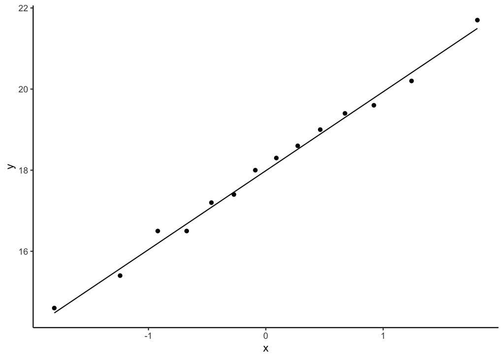

```r
p <- ggplot(jobs, aes(sample = Job.1))
p <- p + stat_qq()
p <- p + stat_qq_line()
p <- p+  theme_classic()
p
```

For computing graduates:

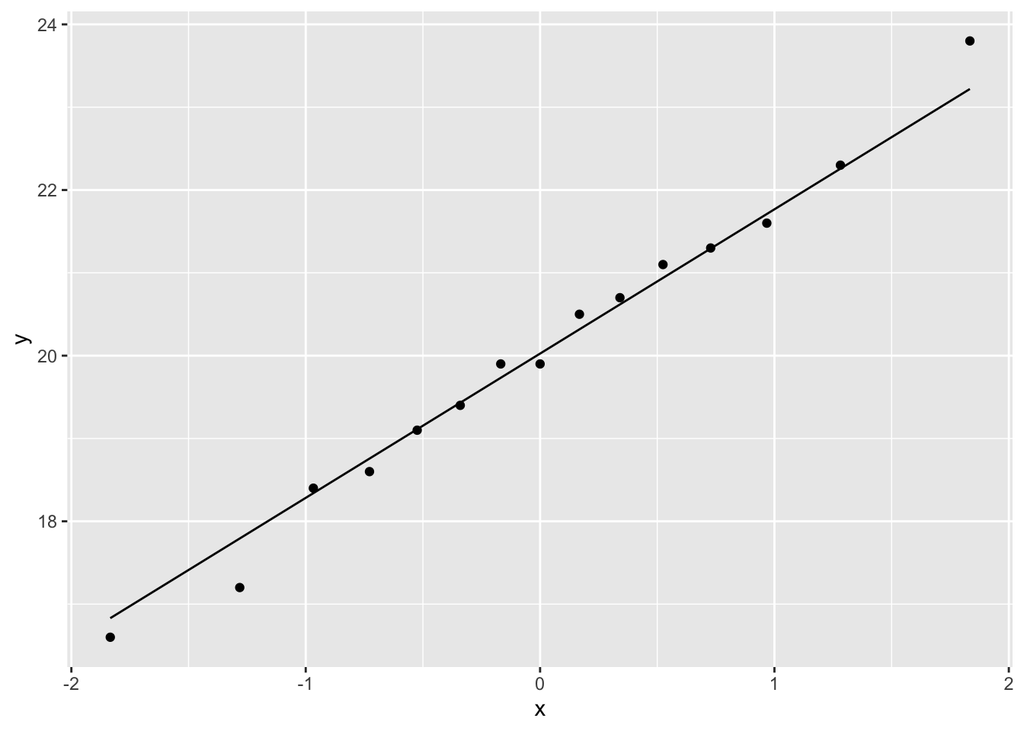

```r
p <- ggplot(jobs, aes(sample = Job.2))
p <- p + stat_qq()
p<- p+ stat_qq_line()
p
```

The points look close to the ideal line. It is reasonable to assume that the distribution is normal.

### Shapiro-Wilk normality tests

For business graduates:

```r
shapiro.test(jobs$Job.1)
```

```
##
##  Shapiro-Wilk normality test
##
## data:  jobs$Job.1
## W = 0.99231, p-value = 0.9999
```

For computing graduates:

```r
shapiro.test(jobs$Job.2)
```

```
##
##  Shapiro-Wilk normality test
##
## data:  jobs$Job.2
## W = 0.99095, p-value = 0.9997
```

The p-values are greater than 0.05, so the normality test is passed.

## Pooled 2-sample t-test

Ho: NULL hypothesis - there is no difference between the graduate jobs starting salary means.

H1: Alternative hypothesis – there is a difference between the graduate jobs starting salary means.

Set var.equal to true to assume equal variance (pooled).

```r
t.test(jobs$Job.1, y=jobs$Job.2 , alternative = "two.sided", paired=F, var.equal= T, mu= 0, conf.level=0.99)
```

```
##
##  Two Sample t-test
##
## data:  jobs$Job.1 and jobs$Job.2
## t = -2.8032, df = 27, p-value = 0.009254
## alternative hypothesis: true difference in means is not equal to 0
## 99 percent confidence interval:
##  -3.97302566 -0.02316481
## sample estimates:
## mean of x mean of y
##  18.02857  20.02667
```

The p value is smaller than 0.01 so the NULL hypothesis is rejected in favour of the alternative hypothesis – there is a significant difference in means.

# Exercise 2

## a. Dataset creation

```r
classmateTimes <- data.frame(time = c(95.2, 103.5, 105.2, 105.2, 103.4, 102.8, 101.8, 97.9, 107.9   , 105.9, 110.5, 100.2))
```

## b. Calculation of confidence intervals

The calculations appear below. Note that a t-testcould have been used to the confidence intervals.

```r
# number of instances of data
n <- length(classmateTimes$time)

# Confidence and significance values (at 95% and 99%)
confidence1 <- 0.95
confidence2 <- 0.99
significance1 <- 1- confidence1
significance2 <- 1- confidence2

halfSignificance1 <- significance1/2
a <- 1 - halfSignificance1
halfSignificance2 <- significance2/2
b <- 1 - halfSignificance2

# degrees of freedom
dfTimes <- n - 1

# finding t-values
t1 <- qt(a, dfTimes)
t2 <- qt(b, dfTimes)

#standard deviation
sdTimes <- sd(classmateTimes$time)

# margin of error at 95% confidence
error1 <- t1*sdTimes/sqrt(n)
# margin of error at 99% confidence
error2 <- t2*sdTimes/sqrt(n)

# mean value
meanTimes <- mean(classmateTimes$time)

# Lower and upper limits at 95% confidence
lowerlimit1 <- meanTimes - error1
upperlimit1 <- meanTimes + error1
# Lower and upper limits at 99% confidence
lowerlimit2 <- meanTimes - error2
upperlimit2 <- meanTimes + error2

# confidence intervals
CI95 <- paste("Confidence interval at 95% confidence is (", lowerlimit1, ", ",  upperlimit1, ")")
CI99 <- paste("Confidence interval at 99% confidence is (", lowerlimit2, ", ",  upperlimit2, ")")
# Outputting the confidence intervals
CI95
```

```
## [1] "Confidence interval at 95% confidence is ( 100.624013780216 ,  105.959319553118 )"
```

```r
CI99
```

```
## [1] "Confidence interval at 99% confidence is ( 99.5273460950588 ,  107.055987238275 )"
```

The interval at 99% confidence has a larger range. Needing more of the observations to fall within the interval requires a wider interval.

## c. Normality tests

### Dot plot

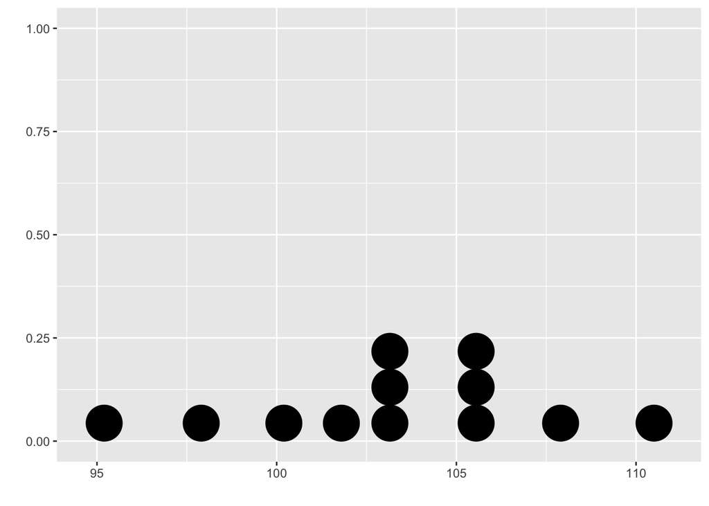

```r
p <- ggplot(classmateTimes, aes(x= time))
p <- p+ geom_dotplot( binwidth=1 )
p <- p + labs( x="",y="")
#p <- p + xlim(370,460)
p
```

The distribution of values looks reasonable, but normality tests need to be carried out.

### Q-Q Plot

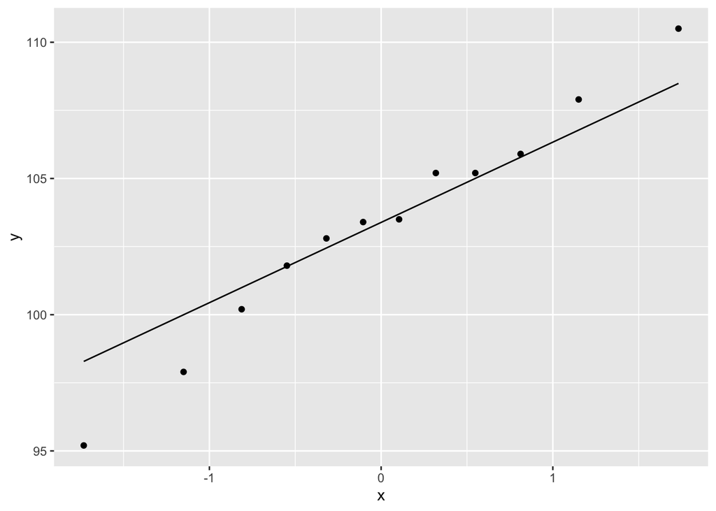

```r
p <- ggplot(classmateTimes, aes(sample = time))
p <- p + stat_qq()
p <- p + stat_qq_line( )
p
```

The points are scatered somehow close to ideal line, although the very top and very bottom points are not quite so close.

### Shapiro Wilk test

```r
shapiro.test(classmateTimes$time)
```

```
##
##  Shapiro-Wilk normality test
##
## data:  classmateTimes$time
## W = 0.98259, p-value = 0.9919
```

The p-value is > 0.05 so it is reasonable to assume that the distribution is normal.

## d. Testing if the mean time is 100

One sample t-test used.

Ho: NULL hypothesis - there is no difference between the mean and value 100.

H1: Alternative hypothesis - the mean differs from 100 seconds.

First test at 95% confidence level.

```r
t.test(classmateTimes$time, alternative = "two.sided", paired=F, mu= 100, conf.level=0.95)
```

```
##
##  One Sample t-test
##
## data:  classmateTimes$time
## t = 2.7158, df = 11, p-value = 0.02008
## alternative hypothesis: true mean is not equal to 100
## 95 percent confidence interval:
##  100.6240 105.9593
## sample estimates:
## mean of x
##  103.2917
```

The p-value is 0.02, which is less than 0.05, so the NULL hypothesis is rejected in favour of the alternative hypothesis. There is evidence that the mean value is greater than 100, as the mean value shown is 103.2917.

Next a test at 99% confidence level is conducted. Note that there is no need to conduct the test below as the p-value will be identical to the one obtained above. The only difference will be that the confidence interval will be wider. AS this exercise does not require looking at confidence intervals, the code below is not needed.

```r
t.test(classmateTimes$time, alternative = "two.sided", paired=F, mu= 100, conf.level=0.99)
```

```
##
##  One Sample t-test
##
## data:  classmateTimes$time
## t = 2.7158, df = 11, p-value = 0.02008
## alternative hypothesis: true mean is not equal to 100
## 99 percent confidence interval:
##   99.52735 107.05599
## sample estimates:
## mean of x
##  103.2917
```

The p-value > 0.01 so the NULL hypothesis cannot be rejected. The evidence is not sufficiently strong to reject the NULL hypothesis.

Note how at 99% confidence the confidence interval includes 100.

# Exercise 3

## a. Dataset creation

```r
fellowTimes <- data.frame(time=c(117.0, 116.3,117.9, 120.0, 125.5, 144.8, 120.6, 120.4, 137.6, 121.7, 123.2, 133.8))
```

## b. Calculation of confidence intervals

The calculations appear below.

```r
# number of instances of data
n <- length(fellowTimes$time)

# Confidence and significance values (at 95% and 99%)
confidence1 <- 0.95
confidence2 <- 0.99
significance1 <- 1- confidence1
significance2 <- 1- confidence2

halfSignificance1 <- significance1/2
a <- 1 - halfSignificance1
halfSignificance2 <- significance2/2
b <- 1 - halfSignificance2

# degrees of freedom
dfTimes <- n - 1

# finding t-values
t1 <- qt(a, dfTimes)
t2 <- qt(b, dfTimes)

#standard deviation
sdTimes <- sd(fellowTimes$time)

# margin of error at 95% confidence
error1 <- t1*sdTimes/sqrt(n)
# margin of error at 99% confidence
error2 <- t2*sdTimes/sqrt(n)

# mean value
meanTimes <- mean(fellowTimes$time)

# Lower and upper limits at 95% confidence
lowerlimit1 <- meanTimes - error1
upperlimit1 <- meanTimes + error1
# Lower and upper limits at 99% confidence
lowerlimit2 <- meanTimes - error2
upperlimit2 <- meanTimes + error2

# confidence interval
CI95 <- paste("Confidence interval at 95% confidence is (", lowerlimit1, ", ",  upperlimit1, ")")
CI99 <- paste("Confidence interval at 99% confidence is (", lowerlimit2, ", ",  upperlimit2, ")")
# outputting values
CI95
```

```
## [1] "Confidence interval at 95% confidence is ( 119.158870639307 ,  130.641129360693 )"
```

```r
CI99
```

```
## [1] "Confidence interval at 99% confidence is ( 116.798701863918 ,  133.001298136082 )"
```

Note that the above confidence intervals are for the mean.

## c. Normality tests

### Dot plot

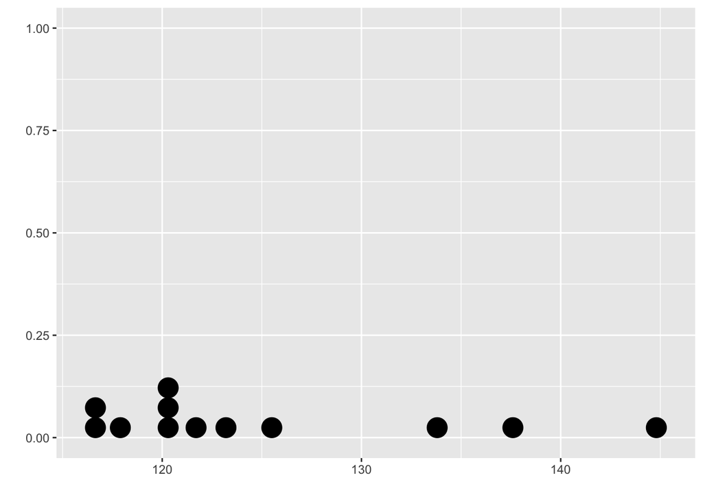

```r
p <- ggplot(fellowTimes, aes(x= time))
p <- p+ geom_dotplot( binwidth=1 )
p <- p + labs( x="",y="")
p
```

The distribution of values does not look normal. The distribution looks positively skewed.

### Q-Q Plot

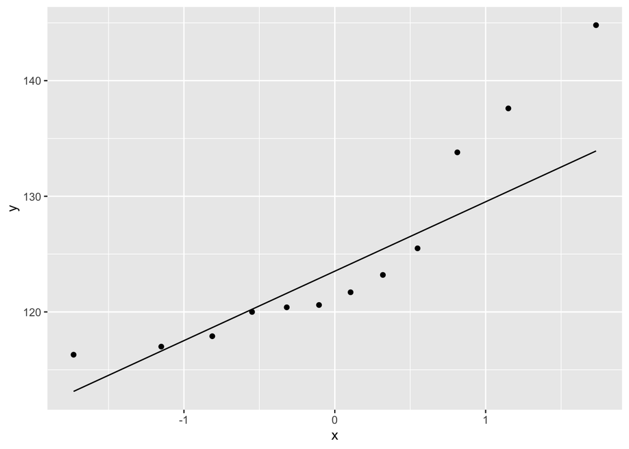

```r
p <- ggplot(fellowTimes, aes(sample = time))
p <- p + stat_qq()
p <- p + stat_qq_line( )
p
```

The points are not that close to ideal line.

### Shapiro Wilk test

```r
shapiro.test(fellowTimes$time)
```

```
##
##  Shapiro-Wilk normality test
##
## data:  fellowTimes$time
## W = 0.83276, p-value = 0.02263
```

The p-value is < 0.05 so it is not reasonable to assume that the distribution is normal.

As it is reasonable to assume that the distribution is not normal, non-parametric tests must be used - i.e. tests based on the median value.

# Exercise 4

## Dataset creation

```r
Week <- c(1:8)
Aberdeen <- c(7820, 6400, 8150, 7360, 7210, 8460, 6770, 7900)
Dundee <- c(6770, 6740, 7290, 7020, 7280, 7950, 6490, 7330)
profits <- data.frame(Week, Aberdeen, Dundee)
```

## b. Normality tests

### Dot plots

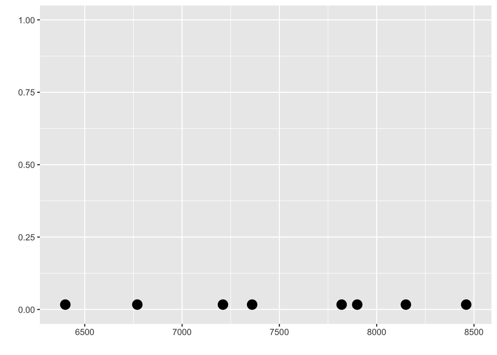

```r
p <- ggplot(profits, aes(x= Aberdeen))
p <- p+ geom_dotplot( binwidth=50)
p <- p + labs( x="",y="")
p
```

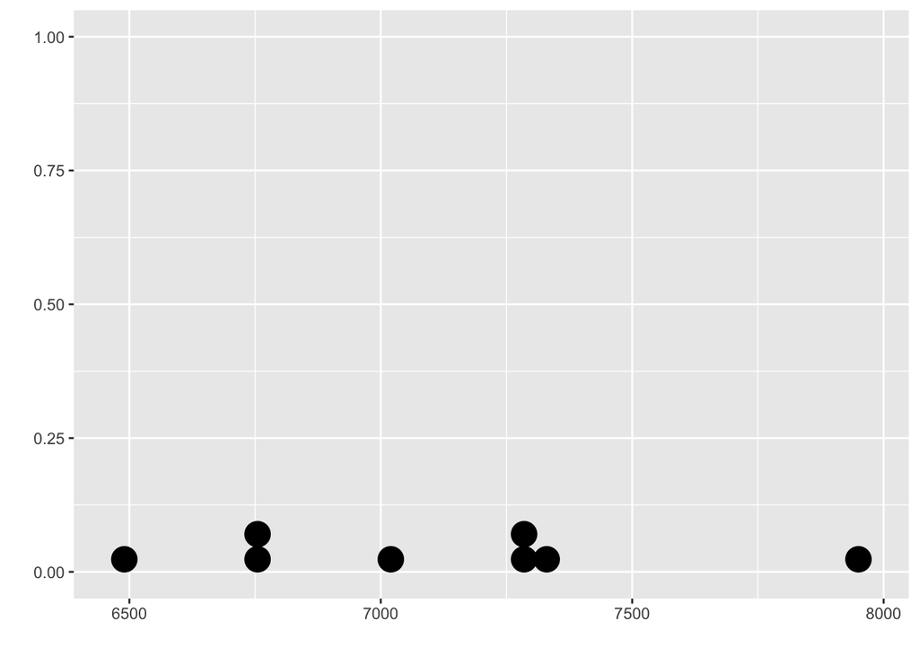

```r
p <- ggplot(profits, aes(x= Dundee))
p <- p+ geom_dotplot( binwidth=50)
p <- p + labs( x="",y="")
p
```

Nothing out of the ordinary observed. Values are scattered.

### Q-Q Plots

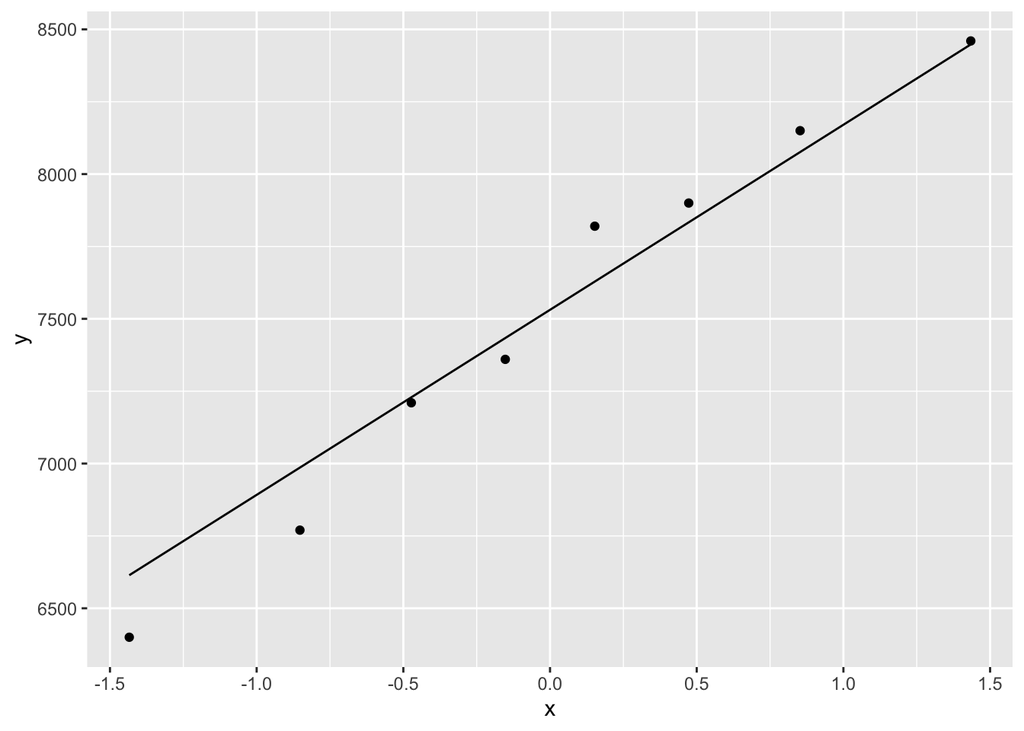

```r
p <- ggplot(profits, aes(sample = Aberdeen))
p <- p + stat_qq()
p <- p + stat_qq_line( )
p
```

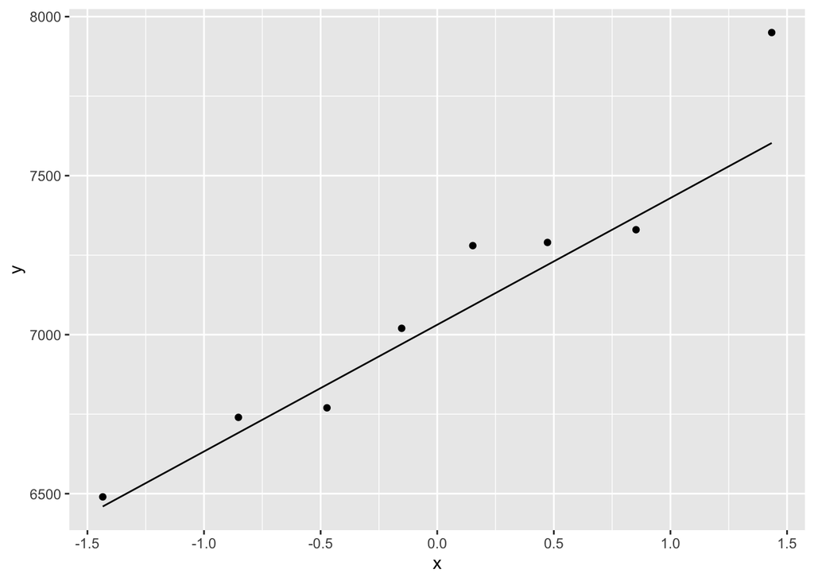

```r
p <- ggplot(profits, aes(sample = Dundee))
p <- p + stat_qq()
p <- p + stat_qq_line( )
p
```

The points are close to ideal line.

### Shapiro Wilk tests

```r
shapiro.test(profits$Aberdeen)
```

```
##
##  Shapiro-Wilk normality test
##
## data:  profits$Aberdeen
## W = 0.96971, p-value = 0.8957
```

```r
shapiro.test(profits$Dundee)
```

```
##
##  Shapiro-Wilk normality test
##
## data:  profits$Dundee
## W = 0.94666, p-value = 0.6775
```

The p-values are > 0.05 so the it is reasonable to assume that the distributions are normal.

### c. Test difference between the profits in Aberdeen and Dundee

Paired t-test

Ho: NULL hypothesis - there is no difference between the two profit means.

H1: Alternative hypothesis – there is a difference between the two profit means.

```r
t.test(x=profits$Aberdeen, y=profits$Dundee , alternative = "two.sided", paired=T, mu= 0, conf.level=0.95)
```

```
##
##  Paired t-test
##
## data:  profits$Aberdeen and profits$Dundee
## t = 2.4759, df = 7, p-value = 0.04246
## alternative hypothesis: true mean difference is not equal to 0
## 95 percent confidence interval:
##   17.98326 782.01674
## sample estimates:
## mean difference
##             400
```

The p-value is less than 0.05 so reject the NULL hypothesis and accept the alternative hypothesis. There is a significant difference in the mean weekly profit. The mean for Aberdeen is higher (the mean of the differences is 400).

At 95% confidence level the mean weekly profits are different. Aberdeen’s are higher.

So let’s conduct a normality test on the difference in profits to ensure the test is valid.

```r
profits$difference <- profits$Aberdeen - profits$Dundee
shapiro.test(profits$difference)
```

```
##
##  Shapiro-Wilk normality test
##
## data:  profits$difference
## W = 0.97798, p-value = 0.9522
```

The p-value > 0.05 so it is reasonable to assume that the difference in profits is normally distributed. The t-test can be used.

# Exercise 5

## a. Dataset creation

```r
Recall.A <- c(71.5, 54.5, 70.2, 65.0, 83.9, 47.9, 49.1, 63.4, 64.2, 57.3, 61.7, 69.6, 75.8)
Recall.B <- c(59.9, 94.4, 67.0, 73.8, 83.3, 76.9, 70.4, 90.7, 75.8, 84.4, 74.7, 74.2, 64.5)
recallIndexing <-data.frame(Recall.A, Recall.B)
```

## b. Normality tests

For Recall.A

```r
shapiro.test(recallIndexing$Recall.A)
```

```
##
##  Shapiro-Wilk normality test
##
## data:  recallIndexing$Recall.A
## W = 0.97741, p-value = 0.9645
```

The p-value is 0.9645 > 0.05, so it is reasonable to assume a normal distribution.

For Recall.B

```r
shapiro.test(recallIndexing$Recall.B)
```

```
##
##  Shapiro-Wilk normality test
##
## data:  recallIndexing$Recall.B
## W = 0.97065, p-value = 0.9019
```

The p-value is 0.9019 > 0.05, so it is reasonable to assume a normal distribution.

## c. Testing for difference in means

Pooled 2-sample t-test

Ho: NULL hypothesis - there is no difference between the recall values for the 2 tools.

H1: Alternative hypothesis – there is a difference between recall values for the 2 tools.

Set var.equal to true to assume equal variance (pooled)

```r
t.test(x=recallIndexing$Recall.A, y=recallIndexing$Recall.B , alternative = "two.sided", paired=F, var.equal= T, mu= 0, conf.level=0.99)
```

```
##
##  Two Sample t-test
##
## data:  recallIndexing$Recall.A and recallIndexing$Recall.B
## t = -3.0098, df = 24, p-value = 0.006063
## alternative hypothesis: true difference in means is not equal to 0
## 99 percent confidence interval:
##  -23.1365998  -0.8480156
## sample estimates:
## mean of x mean of y
##  64.16154  76.15385
```

The p- value is very small, with a value of 0.006063 < 0.05, so reject the NULL hypothesis. There is strong evidence for the mean values of the 2 tools being different, with the mean value for Tool ~B being higher.